# index

## Translation at the Carpentries:

### Technology past, present, and future

Joel Nitta

https://joelnitta.github.io/carpentrycon_2022_trans

## How to translate?

- **Not as simple** as just re-writing text in another language as if translating a novel
- Carpentries lessons are **technical documents** (rendered using software) and therefore present **unique challenges**

## Challenges in technical translation

- Need to be able to **update translation when original changes**
- Need to be able to **deal with source code vs. rendered version**
- Most solutions for translating source code (`gettext` and PO files) are designed with **software** in mind, not prose text

## What is technical translation anyways?

Two aspects:

- internationalization (**i18n**): Providing the **framework** to support translation (requires **technical knowledge**)
- localization (**l10n**): Actually translating strings (requires **linguistic knowlege**)

## Past approach (“Styles” format)

- The current Carpentries lesson format is called the **“Styles” format**

## Past approach (“Styles” format)

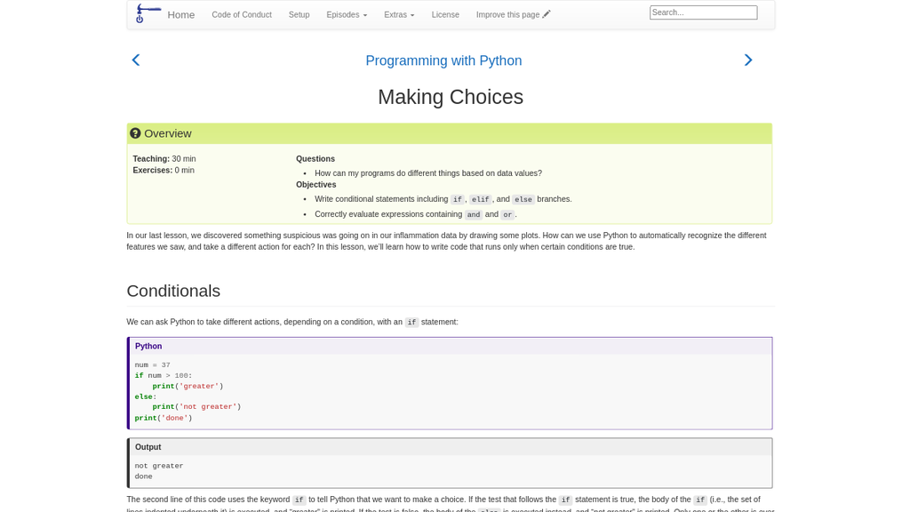

## Past approach (“Styles” format)

- The current Carpentries lesson format is called the **“Styles” format**
- The Styles format is based on **Jekyll** (and some other tools)
- Translation system designed by David Pérez-Suárez used a tool called [PO4gitbook](https://github.com/darkcircle/po4gitbook)

## PO4gitbook

- All translations controlled from a central repo with submodules for each lesson (can traca changes)
- Rendering not possible by typical translator; required David PS to update each time
- No standard system for how to localize
  - transifex (cloud-based)
  - POedit (local text editor)
  - github (online code review; used by JA community)

## New approach (“Workbench” format)

- The upcoming Carpentries lesson format is the **“Workbench” format**

## New approach (“Workbench” format)

[figure not shown]

## New approach (“Workbench” format)

- The upcoming Carpentries lesson format is the **“Workbench” format**
- The Workbench format is based on **Rmarkdown** and **pandoc**
  - Rendering of lessons is greatly simplified
- I am developing an R package to facilitate translating with the Workbench format called dovetail

[figure not shown]

## dovetail

- Each translation is **contained within each lesson**<sup>1</sup>
- Rendering is **easily accomplished locally** by the translator
- Plan to have a standard system for translation (e.g., pushing/pulling from transifex)
[^1]: For now; may change in the future

## dovetail design philosophy

- Make it easier for maintainer to maintain (**`i18n`**)
  - **Not dependent on one person** maintaining one central repo
- Make it easier for translators to translate (**`l10n`**)
  - Requires **minimal technical knowlege** to participate (don’t need git)

**Promote participation in Carpentries by translating!**